# IE582 Homework 1

Sadık Efe Büyükarslan 2019405195

## 1.Introduction

The design of high-performance antennas has become more demanding with the development of high frequency communication systems like 5G technology. In these high frequency systems, there are some standards that the antennas have to satisfy to perform effective signal transmission and reception across specified frequency intervals. During the design phase, the prediction of antenna characteristics and its performance using traditional electromagnetic simulations is computationally intensive. Therefore, it is difficult to conduct trial and error procedure to find out whether the antenna would meet the requirements. As an alternative way, the machine learning methods are intended to be used in this study to make inferences about the relation between the design parameters and the S11 parameter over multiple frequencies which is the measure of reflection.

## 2.Methodologies

To reveal the relation between the design parameters and the S11 parameter (return loss), the design parameters and their ranges given in Table 1 (in the homework pdf file) are used for sampling. In other words, some sample geometries which are in accordance with the given ranges are generated randomly and their performances are obtained with the help of an electromagnetic solver (simulation). The simulations are conducted within the frequency band of 23-33 GHz. After obtaining the sample antenna performances as output, the input dataset including the design/geometry parameters and the output dataset are analyzed using the dimensionality reduction and supervised learning techniques. More specifically, principal component analysis (PCA) and linear regression method are employed as the main methodologies in this study. PCA is particularly applied to the input dataset to reduce the complexity of the design space and more details about the dimensionality reduction with the PCA is discussed in Section 3.1. On the other hand, linear regression models are introduced to examine how the design parameters affect the S11 parameter and to predict the antenna performance based on the given design parameters. The work related to linear regression method is discussed detailly in Section 3.2. The aim of applying these methods is to detect the key parameters and clarify the relationship between the antenna's design parameters and its electromagnetic performance, as represented by the S11 parameter. Additionally, the performance of these methods is evaluated and the interpretation of the results is provided in Section 3.3.

### Data

As it is mentioned previously, the data used in this homework is obtained through the simulation. The data has 385 designs/samples of geometries and these sample geometries include 11 design parameters, or in other words, features. The features are patch length, patch width, probe radius, metal thickness, substrate thickness, solder resist thickness, pad-probe radius difference, patch length ratio, substrate dielectric constant and solder resist dielectric constant. Shortly, the input data is the 385x11 data matrix which includes the design parameter values for corresponding samples. On the output side, there are 2 data matrices which indicates the S parameter value of the each sample for the 201 frequency points. More clearly, the output data consists of two 385x201 data matrices in which each column represents the return loss calculated at a specific frequency point. In total, there are 201 different frequency points. With two matrices, one of the data matrices represents the real part of the S11 parameter and the other one represents the imaginary part of the S11 parameter.

```python
#Import libraries
import numpy as np
import pandas as pd
import seaborn as sns
from sklearn.preprocessing import StandardScaler
from sklearn.decomposition import PCA
from sklearn.linear_model import LinearRegression
from sklearn.model_selection import train_test_split
from sklearn.metrics import mean_squared_error, r2_score
import matplotlib
import matplotlib.pylab as plt
```

```python
#Load the input and output data
input_data = pd.read_csv("hw1_input.csv")
real_output_data = pd.read_csv("hw1_real.csv")
img_output_data = pd.read_csv("hw1_img.csv")
```

```python
#Display the input data
display(input_data)
```

|  | length of patch | width of patch | height of patch | height of substrate | height of solder resist layer | radius of the probe | c_pad | c_antipad | c_probe | dielectric constant of substrate | dielectric constant of solder resist layer |
| --- | --- | --- | --- | --- | --- | --- | --- | --- | --- | --- | --- |
| 0 | 3.202024 | 2.288742 | 0.012514 | 0.139247 | 0.041757 | 0.028566 | 0.000549 | 0.032403 | 0.348140 | 3.735926 | 4.278575 |
| 1 | 2.107848 | 2.895504 | 0.037171 | 0.149492 | 0.056775 | 0.028930 | 0.005536 | 0.053647 | 0.326369 | 4.929862 | 4.876068 |
| 2 | 3.252113 | 4.818411 | 0.025432 | 0.578834 | 0.029972 | 0.030922 | 0.020274 | 0.049845 | 0.446639 | 4.772670 | 4.745106 |
| 3 | 4.161509 | 2.294309 | 0.011058 | 0.117266 | 0.093223 | 0.017604 | 0.001135 | 0.098610 | 0.055665 | 4.102438 | 3.755671 |
| 4 | 4.820912 | 2.948325 | 0.019658 | 0.163503 | 0.094337 | 0.025757 | 0.021725 | 0.072813 | 0.272282 | 2.531031 | 3.047553 |
| ... | ... | ... | ... | ... | ... | ... | ... | ... | ... | ... | ... |
| 380 | 3.950131 | 5.165856 | 0.034389 | 0.770787 | 0.095579 | 0.025591 | 0.011430 | 0.048502 | 0.241219 | 4.099788 | 4.635040 |
| 381 | 2.676373 | 2.826965 | 0.011377 | 0.106795 | 0.055925 | 0.042376 | 0.005102 | 0.060532 | 0.294000 | 4.758303 | 4.205687 |
| 382 | 4.406785 | 1.814310 | 0.011187 | 0.146086 | 0.049041 | 0.040626 | 0.022849 | 0.033737 | 0.225794 | 2.826602 | 4.908306 |
| 383 | 2.540721 | 3.310983 | 0.015000 | 0.135650 | 0.082388 | 0.043490 | 0.011130 | 0.033451 | 0.370502 | 3.303852 | 4.764701 |
| 384 | 2.425315 | 4.998480 | 0.029217 | 0.605634 | 0.028654 | 0.037827 | 0.005896 | 0.033075 | 0.215161 | 4.354493 | 2.676568 |

385 rows × 11 columns

```python
#Display the summary of the statistics of the features
display(input_data.describe())
```

|  | length of patch | width of patch | height of patch | height of substrate | height of solder resist layer | radius of the probe | c_pad | c_antipad | c_probe | dielectric constant of substrate | dielectric constant of solder resist layer |
| --- | --- | --- | --- | --- | --- | --- | --- | --- | --- | --- | --- |
| count | 385.000000 | 385.000000 | 385.000000 | 385.000000 | 385.000000 | 385.000000 | 385.000000 | 385.000000 | 385.000000 | 385.000000 | 385.000000 |
| mean | 3.569210 | 3.536983 | 0.024273 | 0.347643 | 0.060065 | 0.032198 | 0.012797 | 0.060648 | 0.245586 | 3.704384 | 3.521911 |
| std | 0.966173 | 1.182100 | 0.008800 | 0.272738 | 0.023670 | 0.010352 | 0.007111 | 0.021503 | 0.111245 | 0.853877 | 0.871233 |
| min | 1.805658 | 1.801273 | 0.010008 | 0.100321 | 0.020039 | 0.015012 | 0.000003 | 0.025292 | 0.050810 | 2.023380 | 2.001679 |
| 25% | 2.755534 | 2.501163 | 0.016194 | 0.126901 | 0.038689 | 0.023389 | 0.006985 | 0.042011 | 0.148565 | 2.998152 | 2.783710 |
| 50% | 3.637716 | 3.215396 | 0.024198 | 0.155254 | 0.060764 | 0.030979 | 0.012454 | 0.060532 | 0.245049 | 3.866295 | 3.480916 |
| 75% | 4.369311 | 4.829731 | 0.031688 | 0.649324 | 0.080247 | 0.041819 | 0.019014 | 0.078227 | 0.340203 | 4.375551 | 4.278575 |
| max | 5.199919 | 5.198689 | 0.039843 | 0.799082 | 0.099728 | 0.049960 | 0.024996 | 0.099945 | 0.449599 | 4.999324 | 4.999950 |

```python
#Pairwise Correlations
input_data.corr()
```

|  | length of patch | width of patch | height of patch | height of substrate | height of solder resist layer | radius of the probe | c_pad | c_antipad | c_probe | dielectric constant of substrate | dielectric constant of solder resist layer |
| --- | --- | --- | --- | --- | --- | --- | --- | --- | --- | --- | --- |
| length of patch | 1.000000 | -0.114174 | -0.026032 | -0.064344 | 0.044502 | -0.069905 | -0.005560 | -0.009627 | 0.081735 | -0.037448 | -0.014496 |
| width of patch | -0.114174 | 1.000000 | 0.091726 | 0.923739 | -0.021056 | 0.035675 | -0.044198 | -0.013358 | 0.029999 | 0.442193 | 0.038746 |
| height of patch | -0.026032 | 0.091726 | 1.000000 | 0.082833 | 0.036045 | 0.030689 | 0.002422 | 0.037583 | 0.031592 | -0.044318 | -0.037769 |
| height of substrate | -0.064344 | 0.923739 | 0.082833 | 1.000000 | -0.011870 | 0.017410 | -0.031571 | -0.009432 | 0.044166 | 0.459847 | 0.002421 |
| height of solder resist layer | 0.044502 | -0.021056 | 0.036045 | -0.011870 | 1.000000 | -0.012756 | -0.018044 | -0.017071 | 0.024842 | -0.010967 | -0.038405 |
| radius of the probe | -0.069905 | 0.035675 | 0.030689 | 0.017410 | -0.012756 | 1.000000 | 0.002906 | -0.000523 | 0.048088 | -0.025728 | 0.007524 |
| c_pad | -0.005560 | -0.044198 | 0.002422 | -0.031571 | -0.018044 | 0.002906 | 1.000000 | 0.067678 | -0.015500 | -0.049318 | 0.015284 |
| c_antipad | -0.009627 | -0.013358 | 0.037583 | -0.009432 | -0.017071 | -0.000523 | 0.067678 | 1.000000 | -0.132321 | -0.016741 | 0.067821 |
| c_probe | 0.081735 | 0.029999 | 0.031592 | 0.044166 | 0.024842 | 0.048088 | -0.015500 | -0.132321 | 1.000000 | 0.015640 | -0.029101 |
| dielectric constant of substrate | -0.037448 | 0.442193 | -0.044318 | 0.459847 | -0.010967 | -0.025728 | -0.049318 | -0.016741 | 0.015640 | 1.000000 | 0.060402 |
| dielectric constant of solder resist layer | -0.014496 | 0.038746 | -0.037769 | 0.002421 | -0.038405 | 0.007524 | 0.015284 | 0.067821 | -0.029101 | 0.060402 | 1.000000 |

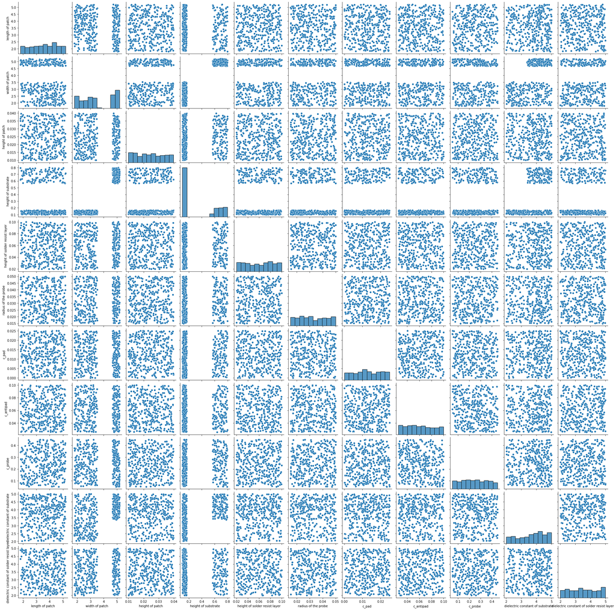

```python
#Pairwise scatter plots
sns.pairplot(input_data)
```

## 3.1 - Dimension Reduction with PCA

In order to apply the PCA to input data, firstly, the data is needed to be standardized. It is because the range of features differ, they are in different scales and the features with large variances would affect the principal components more. After the input data is standardized, the PCA is applied to the standardized data.

```python
#Data preprocessing - Standardize the input data
scaler = StandardScaler()
input_data_std = pd.DataFrame(scaler.fit_transform(input_data), columns = input_data.columns)
#Display the standardized input data
display(input_data_std)
```

|  | length of patch | width of patch | height of patch | height of substrate | height of solder resist layer | radius of the probe | c_pad | c_antipad | c_probe | dielectric constant of substrate | dielectric constant of solder resist layer |
| --- | --- | --- | --- | --- | --- | --- | --- | --- | --- | --- | --- |
| 0 | -0.380536 | -1.057327 | -1.338036 | -0.765082 | -0.774472 | -0.351267 | -1.724662 | -1.315281 | 0.923074 | 0.036988 | 0.869628 |
| 1 | -1.514495 | -0.543367 | 1.467538 | -0.727471 | -0.139201 | -0.316141 | -1.022443 | -0.326035 | 0.727110 | 1.437061 | 1.556322 |
| 2 | -0.328626 | 1.085437 | 0.131827 | 0.848773 | -1.272998 | -0.123460 | 1.052887 | -0.503034 | 1.809644 | 1.252729 | 1.405808 |
| 3 | 0.613834 | -1.052611 | -1.503664 | -0.845779 | 1.402635 | -1.411656 | -1.642198 | 1.767754 | -1.709451 | 0.466780 | 0.268659 |
| 4 | 1.297212 | -0.498624 | -0.525081 | -0.676031 | 1.449735 | -0.622998 | 1.257188 | 0.566491 | 0.240287 | -1.375936 | -0.545176 |
| ... | ... | ... | ... | ... | ... | ... | ... | ... | ... | ... | ... |
| 380 | 0.394770 | 1.379742 | 1.151041 | 1.553487 | 1.502268 | -0.639081 | -0.192424 | -0.565600 | -0.039308 | 0.463672 | 1.279310 |
| 381 | -0.925300 | -0.601423 | -1.467386 | -0.884223 | -0.175149 | 0.984496 | -1.083600 | -0.005410 | 0.435766 | 1.235881 | 0.785859 |
| 382 | 0.868028 | -1.459196 | -1.488972 | -0.739974 | -0.466370 | 0.815233 | 1.415505 | -1.253144 | -0.178147 | -1.029334 | 1.593372 |
| 383 | -1.065884 | -0.191434 | -1.055170 | -0.778287 | 0.944283 | 1.092206 | -0.234769 | -1.266469 | 1.124351 | -0.469685 | 1.428329 |
| 384 | -1.185485 | 1.237966 | 0.562464 | 0.947161 | -1.328763 | 0.544495 | -0.971766 | -1.283949 | -0.273854 | 0.762352 | -0.971545 |

385 rows × 11 columns

```python
#Apply PCA to the standardized input data
pca = PCA()
pca_feature = pca.fit(input_data_std)
explained_variance = pca_feature.explained_variance_ratio_
cumulative_explained_variance = explained_variance.cumsum()
variance_data = [explained_variance,cumulative_explained_variance]
components = pca.components_
loadings = pd.DataFrame(components, columns=input_data_std.columns, index=[f'principal component {i+1}' for i in range(len(components))])
loadings_transposed = loadings.T
explained_variance_df = pd.DataFrame(variance_data, columns = [f'principal component {i+1}' for i in range(len(components))],index=["Explained Variance Ratio", "Cumulative Explained Variance Ratio"])
#Display the loadings
display(loadings_transposed)
```

|  | principal component 1 | principal component 2 | principal component 3 | principal component 4 | principal component 5 | principal component 6 | principal component 7 | principal component 8 | principal component 9 | principal component 10 | principal component 11 |
| --- | --- | --- | --- | --- | --- | --- | --- | --- | --- | --- | --- |
| length of patch | -0.101327 | -0.315409 | -0.369645 | 0.376883 | -0.409833 | 0.073314 | -0.253331 | -0.454266 | -0.406238 | -0.036934 | -0.036141 |
| width of patch | 0.624178 | 0.009718 | 0.040766 | 0.039631 | -0.012169 | -0.032326 | 0.000413 | -0.022090 | -0.040157 | -0.328516 | -0.704172 |
| height of patch | 0.071054 | -0.055716 | 0.620460 | 0.392974 | -0.017701 | 0.069714 | -0.490098 | 0.317943 | -0.216559 | 0.243013 | 0.006071 |
| height of substrate | 0.624137 | -0.018824 | 0.016441 | 0.076518 | -0.028012 | -0.060565 | 0.002837 | -0.059481 | -0.038186 | -0.305362 | 0.708004 |
| height of solder resist layer | -0.021049 | -0.266259 | 0.086417 | 0.510652 | 0.124629 | 0.459841 | 0.647199 | 0.110408 | 0.040184 | -0.027430 | -0.004432 |
| radius of the probe | 0.025997 | -0.002815 | 0.548381 | -0.454397 | -0.218986 | 0.304908 | 0.212779 | -0.491478 | -0.240280 | 0.080764 | 0.010532 |
| c_pad | -0.054228 | 0.265990 | 0.144827 | 0.177533 | -0.580059 | -0.547579 | 0.429976 | 0.174386 | -0.140321 | 0.049041 | -0.010954 |
| c_antipad | -0.018720 | 0.559499 | 0.088323 | 0.373926 | -0.127759 | 0.172140 | -0.138146 | -0.415883 | 0.548589 | -0.000574 | -0.006460 |
| c_probe | 0.039213 | -0.564753 | 0.093131 | -0.151004 | -0.487544 | 0.016285 | -0.102528 | 0.129279 | 0.618694 | 0.000912 | -0.008289 |
| dielectric constant of substrate | 0.445100 | 0.012829 | -0.256167 | -0.022492 | -0.012254 | 0.027772 | 0.097290 | -0.053226 | 0.031927 | 0.849121 | -0.018678 |
| dielectric constant of solder resist layer | 0.038422 | 0.350944 | -0.255339 | -0.184975 | -0.420314 | 0.591708 | -0.086813 | 0.460296 | -0.145645 | -0.087887 | 0.028625 |

```python
#Display the explained variance ratios
display(explained_variance_df)
```

|  | principal component 1 | principal component 2 | principal component 3 | principal component 4 | principal component 5 | principal component 6 | principal component 7 | principal component 8 | principal component 9 | principal component 10 | principal component 11 |
| --- | --- | --- | --- | --- | --- | --- | --- | --- | --- | --- | --- |
| Explained Variance Ratio | 0.207153 | 0.110708 | 0.100034 | 0.096072 | 0.091871 | 0.088458 | 0.085659 | 0.081651 | 0.073399 | 0.058303 | 0.006692 |
| Cumulative Explained Variance Ratio | 0.207153 | 0.317862 | 0.417896 | 0.513968 | 0.605839 | 0.694297 | 0.779956 | 0.861607 | 0.935005 | 0.993308 | 1.000000 |

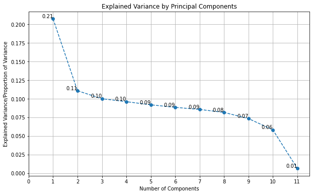

```python
#Plot explained variance by principal components graph
plt.figure(figsize=(10,6))
plt.plot(range(1,len(explained_variance)+1),explained_variance, marker = "o", linestyle = "--")
plt.xticks(range(0,len(explained_variance)+1,1))
plt.title("Explained Variance by Principal Components")
plt.xlabel("Number of Components")
plt.ylabel("Explained Variance/Proportion of Variance")
for i, value in enumerate(explained_variance):
    plt.text(i + 1, value, f"{value:.2f}", ha='right', va='bottom')
plt.grid(True)
plt.show()
```

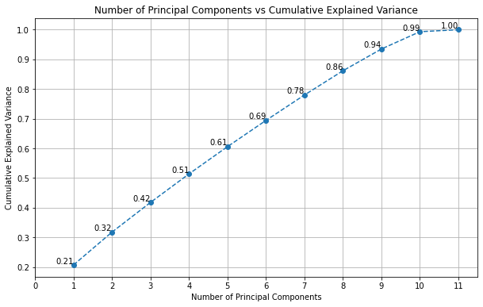

```python
#Plot cumulative explained variance by principal components graph
plt.figure(figsize=(10,6))
plt.plot(range(1,len(cumulative_explained_variance)+1),cumulative_explained_variance, marker = "o", linestyle = "--")
plt.xticks(range(0,len(cumulative_explained_variance)+1,1))
plt.title("Number of Principal Components vs Cumulative Explained Variance")
plt.xlabel("Number of Principal Components")
plt.ylabel("Cumulative Explained Variance")
for i, value in enumerate(cumulative_explained_variance):
    plt.text(i + 1, value, f"{value:.2f}", ha='right', va='bottom')
plt.grid(True)
plt.show()
```

The selection of principal components can be stoppped once 80-90% of the total variance is explained. Based on this rule, the first 8 principal components seems to be favorable for explaining most of the total variance. By applying PCA to the input data, the effective geometric parameters/features can be identified and the dimensionality can be reduced from 11 features to 8 features while preserving most of the variance information. In other words, the design space can be simplified. Numerically, 86% of the total variance is captured with 8 principal components.

```python
#Decomposing the first principal component
pc1 = components[0]
display(pc1)
```

```
array([-0.10132741,  0.62417829,  0.07105448,  0.62413737, -0.02104923,
        0.02599671, -0.05422779, -0.01872008,  0.03921288,  0.44510015,
        0.0384219 ])
```

The proportions of first (length of patch), second (width of patch), forth (height of substrate) and tenth (dielectric constant of substrate) features dominate the other coefficients. By looking the signs of them, it can be reached that width of patch, height of substrate and dielectric constant of substrate affect the principal component in a similar fashion (positively correlated) whereas, length of patch affects it in an opposite fashion meaning that while the length of patch increases the PC1 decreases. From this, it can be concluded that length of patch and the other three features affect the performance measure of S11 parameter in different directions. Other than that, it is likely that width of patch and height of substrate are important features for electromagnetic behavior since they have large coefficients in the principal component 1 (which explains the variability most and much more than the other features).

## 3.2 - Regression Modeling for S11

```python
#Display real output data
display(real_output_data)
```

|  | 0 | 1 | 2 | 3 | 4 | 5 | 6 | 7 | 8 | 9 | ... | 191 | 192 | 193 | 194 | 195 | 196 | 197 | 198 | 199 | 200 |
| --- | --- | --- | --- | --- | --- | --- | --- | --- | --- | --- | --- | --- | --- | --- | --- | --- | --- | --- | --- | --- | --- |
| 0 | 0.649471 | 0.608623 | 0.563770 | 0.515485 | 0.464365 | 0.411022 | 0.356056 | 0.300044 | 0.243525 | 0.186992 | ... | -0.895451 | -0.894250 | -0.893045 | -0.891835 | -0.890620 | -0.889402 | -0.888178 | -0.886951 | -0.885718 | -0.884482 |
| 1 | -0.684443 | -0.680926 | -0.677355 | -0.673727 | -0.670041 | -0.666296 | -0.662491 | -0.658624 | -0.654692 | -0.650696 | ... | -0.835303 | -0.832276 | -0.829209 | -0.826105 | -0.822965 | -0.819791 | -0.816584 | -0.813346 | -0.810078 | -0.806782 |
| 2 | 0.670194 | 0.678183 | 0.685886 | 0.693294 | 0.700399 | 0.707191 | 0.713661 | 0.719799 | 0.725595 | 0.731037 | ... | 0.693171 | 0.675653 | 0.656992 | 0.637113 | 0.615936 | 0.593384 | 0.569383 | 0.543870 | 0.516796 | 0.488139 |
| 3 | -0.856026 | -0.854962 | -0.853892 | -0.852815 | -0.851731 | -0.850642 | -0.849545 | -0.848442 | -0.847333 | -0.846217 | ... | -0.115205 | -0.096197 | -0.076456 | -0.055953 | -0.034660 | -0.012550 | 0.010402 | 0.034219 | 0.058921 | 0.084521 |
| 4 | -0.952876 | -0.951901 | -0.950906 | -0.949892 | -0.948860 | -0.947811 | -0.946747 | -0.945668 | -0.944575 | -0.943469 | ... | -0.692349 | -0.690720 | -0.689088 | -0.687453 | -0.685813 | -0.684171 | -0.682524 | -0.680874 | -0.679221 | -0.677564 |
| ... | ... | ... | ... | ... | ... | ... | ... | ... | ... | ... | ... | ... | ... | ... | ... | ... | ... | ... | ... | ... | ... |
| 380 | 0.712664 | 0.703017 | 0.692973 | 0.682540 | 0.671727 | 0.660545 | 0.649007 | 0.637130 | 0.624930 | 0.612431 | ... | 0.548479 | 0.560256 | 0.571626 | 0.582598 | 0.593180 | 0.603380 | 0.613208 | 0.622674 | 0.631789 | 0.640562 |
| 381 | -0.304243 | -0.267997 | -0.229050 | -0.187238 | -0.142418 | -0.094486 | -0.043392 | 0.010828 | 0.068016 | 0.127852 | ... | -0.898600 | -0.897598 | -0.896590 | -0.895579 | -0.894562 | -0.893540 | -0.892514 | -0.891483 | -0.890447 | -0.889406 |
| 382 | -0.985887 | -0.986109 | -0.986290 | -0.986434 | -0.986540 | -0.986612 | -0.986650 | -0.986656 | -0.986631 | -0.986577 | ... | -0.831635 | -0.830253 | -0.828863 | -0.827464 | -0.826056 | -0.824640 | -0.823215 | -0.821781 | -0.820338 | -0.818886 |
| 383 | -0.696270 | -0.692488 | -0.688645 | -0.684740 | -0.680771 | -0.676737 | -0.672637 | -0.668469 | -0.664232 | -0.659923 | ... | -0.906488 | -0.906808 | -0.906959 | -0.906948 | -0.906784 | -0.906473 | -0.906022 | -0.905439 | -0.904728 | -0.903896 |
| 384 | 0.689258 | 0.681693 | 0.674312 | 0.667233 | 0.660581 | 0.654481 | 0.649055 | 0.644419 | 0.640675 | 0.637908 | ... | 0.536188 | 0.546594 | 0.556813 | 0.566843 | 0.576688 | 0.586347 | 0.595821 | 0.605112 | 0.614219 | 0.623143 |

385 rows × 201 columns

```python
#Display imaginary output data
display(img_output_data)
```

|  | 0 | 1 | 2 | 3 | 4 | 5 | 6 | 7 | 8 | 9 | ... | 191 | 192 | 193 | 194 | 195 | 196 | 197 | 198 | 199 | 200 |
| --- | --- | --- | --- | --- | --- | --- | --- | --- | --- | --- | --- | --- | --- | --- | --- | --- | --- | --- | --- | --- | --- |
| 0 | -0.435160 | -0.493311 | -0.547391 | -0.597047 | -0.642027 | -0.682178 | -0.717442 | -0.747848 | -0.773501 | -0.794570 | ... | 0.418737 | 0.421368 | 0.423987 | 0.426592 | 0.429186 | 0.431767 | 0.434335 | 0.436892 | 0.439437 | 0.441969 |
| 1 | 0.710936 | 0.714041 | 0.717157 | 0.720283 | 0.723419 | 0.726566 | 0.729724 | 0.732892 | 0.736070 | 0.739259 | ... | 0.442050 | 0.449451 | 0.456720 | 0.463863 | 0.470884 | 0.477786 | 0.484573 | 0.491249 | 0.497816 | 0.504278 |
| 2 | 0.549842 | 0.537964 | 0.525835 | 0.513455 | 0.500828 | 0.487957 | 0.474844 | 0.461492 | 0.447904 | 0.434083 | ... | -0.518546 | -0.534209 | -0.549582 | -0.564575 | -0.579078 | -0.592957 | -0.606054 | -0.618175 | -0.629093 | -0.638543 |
| 3 | 0.507327 | 0.509092 | 0.510857 | 0.512623 | 0.514389 | 0.516156 | 0.517923 | 0.519690 | 0.521459 | 0.523228 | ... | 0.928563 | 0.927782 | 0.926488 | 0.924621 | 0.922114 | 0.918892 | 0.914873 | 0.909964 | 0.904064 | 0.897060 |
| 4 | 0.249540 | 0.254110 | 0.258618 | 0.263062 | 0.267447 | 0.271772 | 0.276041 | 0.280253 | 0.284410 | 0.288515 | ... | 0.705500 | 0.707018 | 0.708531 | 0.710037 | 0.711538 | 0.713034 | 0.714523 | 0.716007 | 0.717486 | 0.718958 |
| ... | ... | ... | ... | ... | ... | ... | ... | ... | ... | ... | ... | ... | ... | ... | ... | ... | ... | ... | ... | ... | ... |
| 380 | 0.020787 | 0.012613 | 0.004789 | -0.002657 | -0.009699 | -0.016307 | -0.022453 | -0.028109 | -0.033244 | -0.037832 | ... | 0.394561 | 0.391890 | 0.388879 | 0.385560 | 0.381963 | 0.378117 | 0.374047 | 0.369776 | 0.365325 | 0.360715 |
| 381 | 0.848685 | 0.853280 | 0.856312 | 0.857398 | 0.856077 | 0.851804 | 0.843940 | 0.831742 | 0.814364 | 0.790861 | ... | 0.417166 | 0.419325 | 0.421477 | 0.423624 | 0.425764 | 0.427900 | 0.430030 | 0.432154 | 0.434274 | 0.436389 |
| 382 | -0.008603 | -0.003027 | 0.002469 | 0.007887 | 0.013229 | 0.018496 | 0.023691 | 0.028815 | 0.033870 | 0.038858 | ... | 0.533397 | 0.535355 | 0.537310 | 0.539261 | 0.541210 | 0.543155 | 0.545097 | 0.547035 | 0.548970 | 0.550902 |
| 383 | 0.695714 | 0.699151 | 0.702599 | 0.706058 | 0.709528 | 0.713009 | 0.716500 | 0.720002 | 0.723514 | 0.727036 | ... | 0.095298 | 0.106596 | 0.117713 | 0.128651 | 0.139416 | 0.150010 | 0.160438 | 0.170703 | 0.180809 | 0.190759 |
| 384 | 0.170740 | 0.167545 | 0.165215 | 0.163748 | 0.163124 | 0.163299 | 0.164210 | 0.165769 | 0.167868 | 0.170376 | ... | 0.618999 | 0.612836 | 0.606529 | 0.600081 | 0.593496 | 0.586778 | 0.579930 | 0.572956 | 0.565860 | 0.558643 |

385 rows × 201 columns

In the 2 output data, the rows represent the sample and the columns represent the 201 frequency points.

To proceed with the regression modeling for S11, two output data, real and imaginary output, are combined into one single output data by taking the square root of the sum of the squared real and imaginary data. In this single output, the magnitude of the output is calculated since the electromagnetic performance is quantified by the magnitude.

```python
#Calculate the output magnitude
output_data = np.sqrt(real_output_data**2+img_output_data**2)
#Display the output data
display(output_data)
```

|  | 0 | 1 | 2 | 3 | 4 | 5 | 6 | 7 | 8 | 9 | ... | 191 | 192 | 193 | 194 | 195 | 196 | 197 | 198 | 199 | 200 |
| --- | --- | --- | --- | --- | --- | --- | --- | --- | --- | --- | --- | --- | --- | --- | --- | --- | --- | --- | --- | --- | --- |
| 0 | 0.781778 | 0.783440 | 0.785795 | 0.788790 | 0.792359 | 0.796433 | 0.800936 | 0.805793 | 0.810930 | 0.816277 | ... | 0.988520 | 0.988551 | 0.988581 | 0.988610 | 0.988638 | 0.988664 | 0.988690 | 0.988714 | 0.988737 | 0.988759 |
| 1 | 0.986860 | 0.986669 | 0.986470 | 0.986263 | 0.986048 | 0.985824 | 0.985592 | 0.985350 | 0.985100 | 0.984839 | ... | 0.945061 | 0.945880 | 0.946669 | 0.947428 | 0.948158 | 0.948861 | 0.949537 | 0.950188 | 0.950814 | 0.951417 |
| 2 | 0.866883 | 0.865643 | 0.864258 | 0.862724 | 0.861039 | 0.859198 | 0.857199 | 0.855036 | 0.852705 | 0.850202 | ... | 0.865665 | 0.861328 | 0.856551 | 0.851268 | 0.845404 | 0.838870 | 0.831564 | 0.823368 | 0.814148 | 0.803752 |
| 3 | 0.995069 | 0.995055 | 0.995041 | 0.995025 | 0.995009 | 0.994991 | 0.994973 | 0.994953 | 0.994933 | 0.994912 | ... | 0.935682 | 0.932755 | 0.929637 | 0.926312 | 0.922765 | 0.918978 | 0.914932 | 0.910607 | 0.905982 | 0.901033 |
| 4 | 0.985009 | 0.985235 | 0.985447 | 0.985645 | 0.985831 | 0.986005 | 0.986169 | 0.986321 | 0.986464 | 0.986597 | ... | 0.988472 | 0.988418 | 0.988361 | 0.988304 | 0.988244 | 0.988183 | 0.988121 | 0.988057 | 0.987991 | 0.987924 |
| ... | ... | ... | ... | ... | ... | ... | ... | ... | ... | ... | ... | ... | ... | ... | ... | ... | ... | ... | ... | ... | ... |
| 380 | 0.712967 | 0.703130 | 0.692989 | 0.682545 | 0.671797 | 0.660746 | 0.649395 | 0.637749 | 0.625814 | 0.613598 | ... | 0.675654 | 0.683714 | 0.691363 | 0.698625 | 0.705520 | 0.712067 | 0.718286 | 0.724194 | 0.729808 | 0.735143 |
| 381 | 0.901571 | 0.894376 | 0.886417 | 0.877604 | 0.867842 | 0.857028 | 0.845054 | 0.831812 | 0.817200 | 0.801129 | ... | 0.990712 | 0.990714 | 0.990716 | 0.990716 | 0.990715 | 0.990713 | 0.990710 | 0.990706 | 0.990701 | 0.990695 |
| 382 | 0.985925 | 0.986114 | 0.986294 | 0.986465 | 0.986629 | 0.986785 | 0.986934 | 0.987076 | 0.987212 | 0.987341 | ... | 0.987993 | 0.987889 | 0.987783 | 0.987674 | 0.987561 | 0.987445 | 0.987326 | 0.987204 | 0.987078 | 0.986949 |
| 383 | 0.984282 | 0.984049 | 0.983807 | 0.983558 | 0.983300 | 0.983034 | 0.982758 | 0.982473 | 0.982179 | 0.981875 | ... | 0.911483 | 0.913052 | 0.914566 | 0.916027 | 0.917439 | 0.918802 | 0.920118 | 0.921390 | 0.922618 | 0.923805 |
| 384 | 0.710091 | 0.701981 | 0.694257 | 0.687033 | 0.680424 | 0.674545 | 0.669505 | 0.665398 | 0.662302 | 0.660269 | ... | 0.818936 | 0.821178 | 0.823357 | 0.825474 | 0.827530 | 0.829524 | 0.831458 | 0.833330 | 0.835142 | 0.836893 |

385 rows × 201 columns

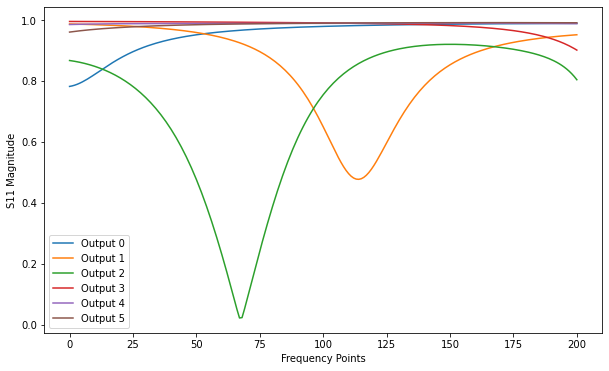

```python
#Plot S11 magnitudes over 201 frequency points for the first 6 designs
plt.figure(figsize=(10, 6))
for i in range(6):
    plt.plot(output_data.iloc[i], label = f"Output {i}")
plt.xticks(range(0,201,25))
plt.xlabel("Frequency Points")
plt.ylabel("S11 Magnitude")
plt.legend()
plt.show()
```

Although the output data is represented in a single output data, the regression modeling is computationally hard since the output data is evaluated at 201 frequency points. To select a few frequency points that are important for regression, two methods are proposed in this section:

Method 1: Assigning weights to the each output and selecting the frequency points with highest weight/score

Method 2: Calculating the variance of each sample output, selecting the ones (samples) with highest variance and taking the sum of them

The main motivation behind these methods is to give importance to the low S11 magnitudes and consider the curves that has minimum magnitudes for selecting the critical frequency points. The reason is that the lower magnitudes mean better reflection performance, less signal loss around that frequency point which is desired in this study. On the other hand, the higher output values and curves like output 0, 3, 4, and 5 represent poor performances in terms of S11 parameter. Thus, these methods try to get rid of samples that have poor performance and to find critical frequency points by focusing on the sample and frequency pairs that show strong performance.

Method 1: Assigning weights to the each output and selecting the frequency points with highest weight/score

In this method, a weight of reciprocal of the magnitude value is given to each output. The reason underlying this weigthing method is to give more weight to the smaller output values. By giving more weight to the smaller output, the weight of frequency points, which is calculated by summing all the weights of output values at that frequency point, is aimed to be adjusted with respect to the desired output. Therefore, it is expected that the frequency points that have higher weights are the key frequencies since the weighting diminishes the effect of samples behave as undesired. Briefly, it's like rewarding the frequency points according to output values at that point.

```python
weighted_output_data = 1/output_data
#Display the weighted output data
display(weighted_output_data)
```

|  | 0 | 1 | 2 | 3 | 4 | 5 | 6 | 7 | 8 | 9 | ... | 191 | 192 | 193 | 194 | 195 | 196 | 197 | 198 | 199 | 200 |
| --- | --- | --- | --- | --- | --- | --- | --- | --- | --- | --- | --- | --- | --- | --- | --- | --- | --- | --- | --- | --- | --- |
| 0 | 1.279135 | 1.276423 | 1.272597 | 1.267765 | 1.262054 | 1.255598 | 1.248539 | 1.241013 | 1.233152 | 1.225075 | ... | 1.011613 | 1.011581 | 1.011550 | 1.011521 | 1.011493 | 1.011465 | 1.011439 | 1.011415 | 1.011391 | 1.011368 |
| 1 | 1.013315 | 1.013511 | 1.013716 | 1.013928 | 1.014150 | 1.014380 | 1.014619 | 1.014867 | 1.015126 | 1.015394 | ... | 1.058133 | 1.057216 | 1.056336 | 1.055490 | 1.054677 | 1.053895 | 1.053145 | 1.052423 | 1.051730 | 1.051064 |
| 2 | 1.153558 | 1.155211 | 1.157062 | 1.159119 | 1.161388 | 1.163876 | 1.166591 | 1.169542 | 1.172739 | 1.176192 | ... | 1.155181 | 1.160998 | 1.167473 | 1.174718 | 1.182867 | 1.192080 | 1.202554 | 1.214524 | 1.228279 | 1.244166 |
| 3 | 1.004956 | 1.004969 | 1.004984 | 1.005000 | 1.005016 | 1.005034 | 1.005053 | 1.005072 | 1.005093 | 1.005114 | ... | 1.068739 | 1.072093 | 1.075689 | 1.079550 | 1.083700 | 1.088166 | 1.092978 | 1.098168 | 1.103775 | 1.109837 |
| 4 | 1.015219 | 1.014986 | 1.014768 | 1.014564 | 1.014372 | 1.014193 | 1.014025 | 1.013869 | 1.013722 | 1.013585 | ... | 1.011662 | 1.011718 | 1.011776 | 1.011835 | 1.011896 | 1.011958 | 1.012022 | 1.012087 | 1.012155 | 1.012224 |
| ... | ... | ... | ... | ... | ... | ... | ... | ... | ... | ... | ... | ... | ... | ... | ... | ... | ... | ... | ... | ... | ... |
| 380 | 1.402590 | 1.422213 | 1.443023 | 1.465105 | 1.488546 | 1.513441 | 1.539894 | 1.568014 | 1.597919 | 1.629732 | ... | 1.480048 | 1.462601 | 1.446417 | 1.431383 | 1.417394 | 1.404361 | 1.392202 | 1.380845 | 1.370223 | 1.360280 |
| 381 | 1.109174 | 1.118098 | 1.128138 | 1.139466 | 1.152283 | 1.166823 | 1.183356 | 1.202194 | 1.223691 | 1.248238 | ... | 1.009375 | 1.009373 | 1.009371 | 1.009371 | 1.009372 | 1.009374 | 1.009377 | 1.009381 | 1.009386 | 1.009392 |
| 382 | 1.014276 | 1.014082 | 1.013897 | 1.013721 | 1.013552 | 1.013392 | 1.013239 | 1.013093 | 1.012954 | 1.012821 | ... | 1.012153 | 1.012259 | 1.012368 | 1.012480 | 1.012596 | 1.012714 | 1.012836 | 1.012962 | 1.013091 | 1.013224 |
| 383 | 1.015969 | 1.016210 | 1.016459 | 1.016717 | 1.016984 | 1.017259 | 1.017544 | 1.017839 | 1.018144 | 1.018459 | ... | 1.097113 | 1.095228 | 1.093415 | 1.091671 | 1.089991 | 1.088374 | 1.086817 | 1.085317 | 1.083872 | 1.082479 |
| 384 | 1.408271 | 1.424540 | 1.440389 | 1.455535 | 1.469672 | 1.482480 | 1.493641 | 1.502859 | 1.509886 | 1.514535 | ... | 1.221096 | 1.217763 | 1.214540 | 1.211424 | 1.208415 | 1.205510 | 1.202707 | 1.200005 | 1.197401 | 1.194896 |

385 rows × 201 columns

```python
#Calculate the weight of each frequency by summing weights at each frequency point
frequency_weights = weighted_output_data.sum(axis=0)
sorted_frequency_weights = frequency_weights.sort_values(ascending=False)
sorted_frequency_weights_df = sorted_frequency_weights.reset_index()
sorted_frequency_weights_df.columns = ['Frequency Points', 'Weights']
#Display the frequency weights in descending order to see the range of weight
display(sorted_frequency_weights_df)
#Display the top 20 frequency points
sorted_frequency_weights_df.head(20)
```

|  | Frequency Points | Weights |
| --- | --- | --- |
| 0 | 71 | 746.463681 |
| 1 | 155 | 663.780596 |
| 2 | 126 | 650.215215 |
| 3 | 88 | 645.831682 |
| 4 | 85 | 641.111722 |
| ... | ... | ... |
| 196 | 5 | 443.092622 |
| 197 | 3 | 442.664621 |
| 198 | 2 | 440.407710 |
| 199 | 1 | 438.535615 |
| 200 | 0 | 437.364375 |

201 rows × 2 columns

|  | Frequency Points | Weights |
| --- | --- | --- |
| 0 | 71 | 746.463681 |
| 1 | 155 | 663.780596 |
| 2 | 126 | 650.215215 |
| 3 | 88 | 645.831682 |
| 4 | 85 | 641.111722 |
| 5 | 154 | 635.081322 |
| 6 | 146 | 634.687831 |
| 7 | 156 | 629.230136 |
| 8 | 149 | 627.493089 |
| 9 | 87 | 627.292062 |
| 10 | 147 | 625.238122 |
| 11 | 144 | 625.235260 |
| 12 | 145 | 623.972627 |
| 13 | 86 | 623.349841 |
| 14 | 28 | 623.039861 |
| 15 | 148 | 621.530899 |
| 16 | 151 | 620.377870 |
| 17 | 150 | 619.680151 |
| 18 | 153 | 619.170286 |
| 19 | 89 | 618.423324 |

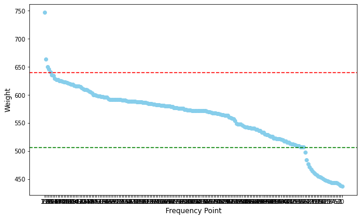

```python
#Plot frequency points vs weights
plt.figure(figsize=(10, 6))
plt.scatter(sorted_frequency_weights_df['Frequency Points'], sorted_frequency_weights_df['Weights'],marker="o", color='skyblue')
plt.axhline(y=640, color='red', linestyle='--')
plt.axhline(y=506, color='green', linestyle='--')
plt.xlabel('Frequency Point', fontsize=12)
plt.ylabel('Weight', fontsize=12)
plt.show()
```

Based on the frequency weights and the frequency points vs weights plot, it is seen that there is a big difference between the high frequency weights and low frequency weights. In the middle portion which is the portion between the red and green line, the weights follow a linear trend, meaning that the difference is not that remarkable. By examining the plot above and the sorted frequency weights, the top 5 frequency points which are 71, 155, 126, 88 and 85 are chosen as key frequency points since the difference in weight gets smaller after the frequency point 85. Moreover, one other important remark is that the frequency point 71 seems to be the most important point among the frequency points by outweighing a lot.

Method 2: Calculating the variance of each sample output, selecting the ones (samples) with highest variance and taking the sum of them

The main idea of this method is to find the key frequency points by taking advantage of the variance of the samples. It can be seen on the graph which consists of output values of the first 6 designs that the samples performing poorly in terms of S11 parameter have less variance compared to the samples which have good performances at some frequencies. In order to avoid the samples that have poor performance and concentrate on the frequencies at which the other samples perform well, the variance of the sample output can be a useful parameter. The reason is that if the variance of the sample output is larger, then it probably performs in a desired fashion at certain frequency values. On the other hand, the bad performing samples have less variance as it can be seen on the plot of S11 magnitude for first 6 designs. After finding out the samples that have the largest variance, it is suggested to take the sum of the output values of those samples to find out which frequency points are critical.

```python
#Calculate the variance of the output data
sample_output_variance = output_data.var(axis=1)
sorted_sample_output_variance = sample_output_variance.sort_values(ascending=False)
sorted_sample_output_variance_df = sorted_sample_output_variance.reset_index()
sorted_sample_output_variance_df.columns = ['Sample Number', 'Variance']
display(sorted_sample_output_variance_df)
sorted_sample_output_variance_df.head(20)
```

|  | Sample Number | Variance |
| --- | --- | --- |
| 0 | 373 | 8.175914e-02 |
| 1 | 15 | 7.324727e-02 |
| 2 | 306 | 6.709813e-02 |
| 3 | 291 | 6.476041e-02 |
| 4 | 141 | 6.190460e-02 |
| ... | ... | ... |
| 380 | 222 | 8.315928e-07 |
| 381 | 4 | 8.239044e-07 |
| 382 | 281 | 6.417835e-07 |
| 383 | 250 | 5.377628e-07 |
| 384 | 119 | 1.171054e-08 |

385 rows × 2 columns

|  | Sample Number | Variance |
| --- | --- | --- |
| 0 | 373 | 0.081759 |
| 1 | 15 | 0.073247 |
| 2 | 306 | 0.067098 |
| 3 | 291 | 0.064760 |
| 4 | 141 | 0.061905 |
| 5 | 270 | 0.061779 |
| 6 | 301 | 0.061389 |
| 7 | 371 | 0.061340 |
| 8 | 351 | 0.059971 |
| 9 | 217 | 0.059770 |
| 10 | 299 | 0.059590 |
| 11 | 282 | 0.059398 |
| 12 | 129 | 0.059347 |
| 13 | 2 | 0.058220 |
| 14 | 294 | 0.058179 |
| 15 | 317 | 0.057550 |
| 16 | 59 | 0.057276 |
| 17 | 170 | 0.056776 |
| 18 | 186 | 0.056599 |
| 19 | 246 | 0.056026 |

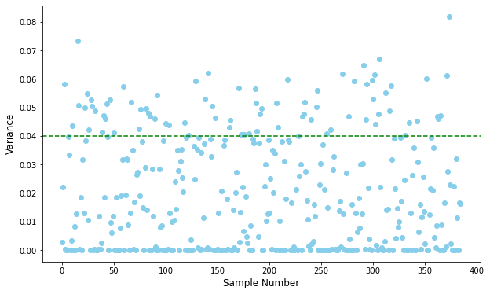

```python
#Plot sample number vs variance
plt.figure(figsize=(10, 6))
plt.scatter(sorted_sample_output_variance_df['Sample Number'], sorted_sample_output_variance_df['Variance'],marker="o", color='skyblue')
plt.axhline(y=0.04, color='green', linestyle='--')
plt.xlabel('Sample Number', fontsize=12)
plt.ylabel('Variance', fontsize=12)
plt.show()
```

Based on the graph, a threshold of variance > 0.04 is set to select the samples. After selecting them, their sum over 201 frequency points are calculated.

```python
filtered_sample_numbers = sorted_sample_output_variance_df[sorted_sample_output_variance_df['Variance'] >= 0.04]['Sample Number']
filtered_output_data = output_data.loc[filtered_sample_numbers]
display(filtered_output_data)
sum_over_frequencies = filtered_output_data.sum(axis=0)
sorted_sum_over_frequencies = sum_over_frequencies.sort_values(ascending=True)
sorted_sum_over_frequencies_df = sorted_sum_over_frequencies.reset_index()
sorted_sum_over_frequencies_df.columns = ['Frequency', 'Sum of Values']
display(sorted_sum_over_frequencies_df)
```

|  | 0 | 1 | 2 | 3 | 4 | 5 | 6 | 7 | 8 | 9 | ... | 191 | 192 | 193 | 194 | 195 | 196 | 197 | 198 | 199 | 200 |
| --- | --- | --- | --- | --- | --- | --- | --- | --- | --- | --- | --- | --- | --- | --- | --- | --- | --- | --- | --- | --- | --- |
| 373 | 0.933913 | 0.932777 | 0.931637 | 0.930494 | 0.929348 | 0.928197 | 0.927043 | 0.925885 | 0.924724 | 0.923558 | ... | 0.174434 | 0.178371 | 0.182647 | 0.187234 | 0.192105 | 0.197234 | 0.202596 | 0.208167 | 0.213924 | 0.219844 |
| 15 | 0.932427 | 0.931309 | 0.930169 | 0.929005 | 0.927819 | 0.926609 | 0.925376 | 0.924121 | 0.922842 | 0.921541 | ... | 0.559430 | 0.567047 | 0.574487 | 0.581754 | 0.588853 | 0.595790 | 0.602568 | 0.609193 | 0.615669 | 0.622000 |
| 306 | 0.948046 | 0.947532 | 0.947013 | 0.946489 | 0.945957 | 0.945417 | 0.944868 | 0.944307 | 0.943733 | 0.943145 | ... | 0.672020 | 0.678730 | 0.685220 | 0.691500 | 0.697578 | 0.703463 | 0.709162 | 0.714682 | 0.720032 | 0.725219 |
| 291 | 0.736471 | 0.732063 | 0.727388 | 0.722441 | 0.717220 | 0.711723 | 0.705945 | 0.699886 | 0.693544 | 0.686916 | ... | 0.815857 | 0.809769 | 0.803198 | 0.796106 | 0.788456 | 0.780207 | 0.771315 | 0.761734 | 0.751417 | 0.740313 |
| 141 | 0.927706 | 0.928077 | 0.928403 | 0.928681 | 0.928913 | 0.929096 | 0.929232 | 0.929320 | 0.929360 | 0.929352 | ... | 0.741928 | 0.747569 | 0.752997 | 0.758220 | 0.763250 | 0.768093 | 0.772759 | 0.777256 | 0.781590 | 0.785769 |
| ... | ... | ... | ... | ... | ... | ... | ... | ... | ... | ... | ... | ... | ... | ... | ... | ... | ... | ... | ... | ... | ... |
| 180 | 0.909834 | 0.908265 | 0.906674 | 0.905060 | 0.903425 | 0.901768 | 0.900090 | 0.898392 | 0.896675 | 0.894937 | ... | 0.514269 | 0.519654 | 0.525003 | 0.530313 | 0.535584 | 0.540815 | 0.546004 | 0.551151 | 0.556256 | 0.561318 |
| 173 | 0.996066 | 0.996037 | 0.996006 | 0.995975 | 0.995944 | 0.995911 | 0.995878 | 0.995844 | 0.995810 | 0.995775 | ... | 0.848350 | 0.857742 | 0.866275 | 0.874045 | 0.881135 | 0.887617 | 0.893556 | 0.899008 | 0.904022 | 0.908641 |
| 176 | 0.849525 | 0.845310 | 0.840953 | 0.836452 | 0.831803 | 0.827004 | 0.822050 | 0.816939 | 0.811667 | 0.806231 | ... | 0.485821 | 0.502304 | 0.517995 | 0.532923 | 0.547115 | 0.560601 | 0.573410 | 0.585572 | 0.597115 | 0.608068 |
| 122 | 0.922408 | 0.921457 | 0.920437 | 0.919346 | 0.918185 | 0.916950 | 0.915642 | 0.914259 | 0.912799 | 0.911261 | ... | 0.524813 | 0.519009 | 0.513627 | 0.508705 | 0.504285 | 0.500403 | 0.497095 | 0.494395 | 0.492330 | 0.490927 |
| 331 | 0.921856 | 0.920188 | 0.918462 | 0.916674 | 0.914822 | 0.912903 | 0.910912 | 0.908846 | 0.906701 | 0.904472 | ... | 0.570183 | 0.561625 | 0.553244 | 0.545089 | 0.537215 | 0.529677 | 0.522531 | 0.515836 | 0.509647 | 0.504021 |

80 rows × 201 columns

|  | Frequency | Sum of Values |
| --- | --- | --- |
| 0 | 80 | 43.433506 |
| 1 | 79 | 43.435729 |
| 2 | 81 | 43.437770 |
| 3 | 78 | 43.444719 |
| 4 | 82 | 43.445256 |
| ... | ... | ... |
| 196 | 4 | 66.355564 |
| 197 | 3 | 66.615665 |
| 198 | 2 | 66.868335 |
| 199 | 1 | 67.113381 |
| 200 | 0 | 67.350671 |

201 rows × 2 columns

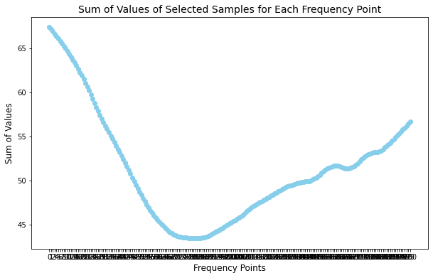

```python
#Plot Sum of Values of Selected Samples for Each Frequency Point
plt.figure(figsize=(10, 6))
plt.plot(sum_over_frequencies, marker='o', color='skyblue', linestyle='-')
plt.title('Sum of Values of Selected Samples for Each Frequency Point', fontsize=14)
plt.xlabel('Frequency Points', fontsize=12)
plt.ylabel('Sum of Values', fontsize=12)
plt.show()
```

At this point, the 5 frequency points that have minimum sum of values are selected since the lower output is preferred. The selected frequency points are 80, 79, 81, 78 and 82.

### Regression Modelling

```
Frequency Point: 71 (Real Part)
Test MSE: 0.0857, R²: 0.8220

Frequency Point: 71 (Imaginary Part)
Test MSE: 0.0871, R²: 0.0385
```

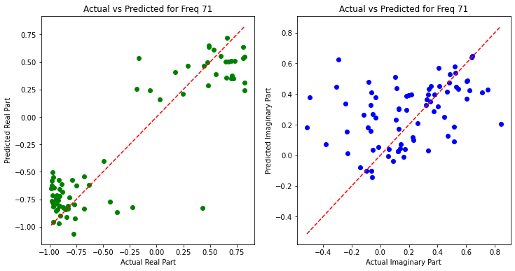

```
Frequency Point: 155 (Real Part)
Test MSE: 0.0721, R²: 0.8158

Frequency Point: 155 (Imaginary Part)
Test MSE: 0.0873, R²: 0.1382
```

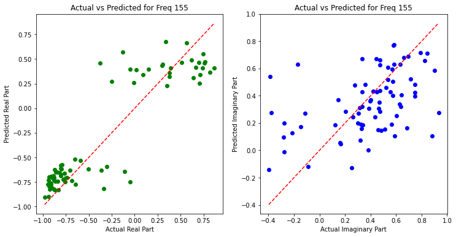

```
Frequency Point: 126 (Real Part)
Test MSE: 0.0785, R²: 0.7936

Frequency Point: 126 (Imaginary Part)
Test MSE: 0.0770, R²: 0.2635
```

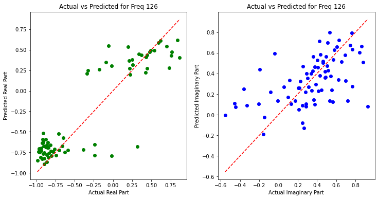

```
Frequency Point: 88 (Real Part)
Test MSE: 0.0572, R²: 0.8744

Frequency Point: 88 (Imaginary Part)
Test MSE: 0.0708, R²: 0.2200
```

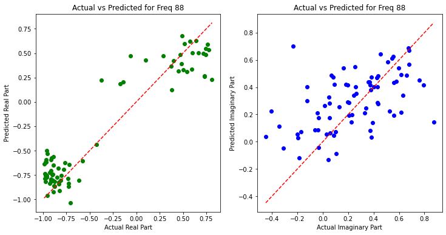

```
Frequency Point: 85 (Real Part)
Test MSE: 0.0572, R²: 0.8758

Frequency Point: 85 (Imaginary Part)
Test MSE: 0.0756, R²: 0.1696
```

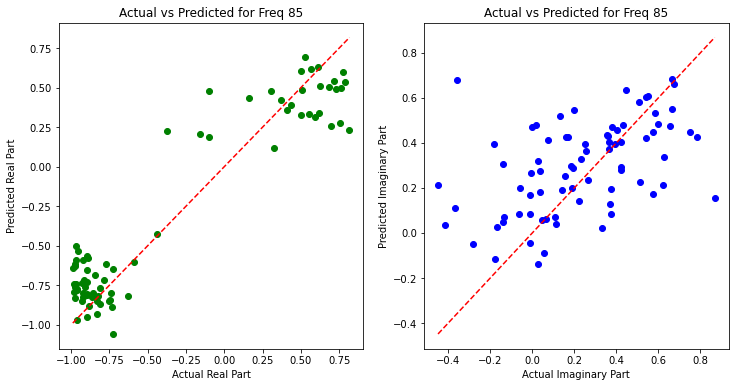

```
Frequency Point: 80 (Real Part)
Test MSE: 0.0604, R²: 0.8702

Frequency Point: 80 (Imaginary Part)
Test MSE: 0.0852, R²: 0.0882
```

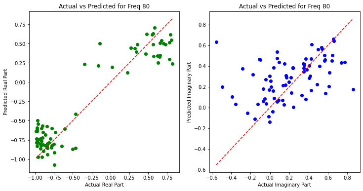

```
Frequency Point: 79 (Real Part)
Test MSE: 0.0623, R²: 0.8662

Frequency Point: 79 (Imaginary Part)
Test MSE: 0.0866, R²: 0.0760
```

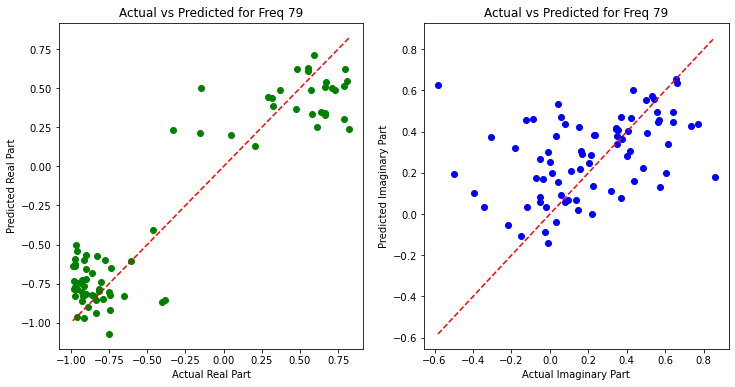

```
Frequency Point: 81 (Real Part)
Test MSE: 0.0590, R²: 0.8729

Frequency Point: 81 (Imaginary Part)
Test MSE: 0.0834, R²: 0.1026
```

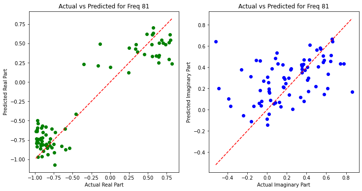

```
Frequency Point: 78 (Real Part)
Test MSE: 0.0649, R²: 0.8610

Frequency Point: 78 (Imaginary Part)
Test MSE: 0.0875, R²: 0.0663
```

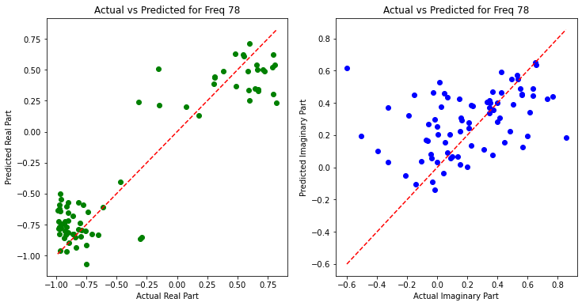

```
Frequency Point: 82 (Real Part)
Test MSE: 0.0581, R²: 0.8746

Frequency Point: 82 (Imaginary Part)
Test MSE: 0.0815, R²: 0.1184
```

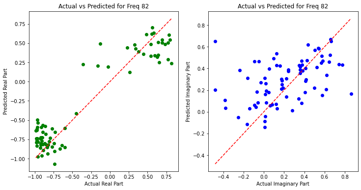

```python
models = {}
evaluation_results = {}
frequency_points_method1 = [71, 155, 126, 88, 85]
frequency_points_method2 = [80, 79, 81, 78, 82]
for method, frequency_points in zip(["method1", "method2"], [frequency_points_method1, frequency_points_method2]):
    for freq in frequency_points:

        y_real = real_output_data.iloc[:, freq]
        y_img = img_output_data.iloc[:, freq]

        X_train, X_test, y_train_real, y_test_real = train_test_split(input_data, y_real, test_size=0.2, random_state=42)
        _, _, y_train_img, y_test_img = train_test_split(input_data, y_img, test_size=0.2, random_state=42)

        model_real = LinearRegression()
        model_real.fit(X_train, y_train_real)
        y_real_pred = model_real.predict(X_test)

        model_img = LinearRegression()
        model_img.fit(X_train, y_train_img)
        y_img_pred = model_img.predict(X_test)

        mse_real = mean_squared_error(y_test_real, y_real_pred)
        r2_real = r2_score(y_test_real, y_real_pred)

        mse_img = mean_squared_error(y_test_img, y_img_pred)
        r2_img = r2_score(y_test_img, y_img_pred)

        print(f"Frequency Point: {freq} (Real Part)")
        print(f"Test MSE: {mse_real:.4f}, R²: {r2_real:.4f}\n")

        print(f"Frequency Point: {freq} (Imaginary Part)")
        print(f"Test MSE: {mse_img:.4f}, R²: {r2_img:.4f}\n")

        # Plot actual vs. predicted values for all test data for both real and imaginary parts
        plt.figure(figsize=(12, 6))

        # Plot real part
        plt.subplot(1, 2, 1)
        plt.scatter(y_test_real, y_real_pred, color='green')
        plt.plot([min(y_test_real), max(y_test_real)], [min(y_test_real), max(y_test_real)], color='red', linestyle='--')
        plt.xlabel('Actual Real Part')
        plt.ylabel('Predicted Real Part')
        plt.title(f'Actual vs Predicted for Freq {freq}')

        # Plot imaginary part
        plt.subplot(1, 2, 2)
        plt.scatter(y_test_img, y_img_pred, color='blue')
        plt.plot([min(y_test_img), max(y_test_img)], [min(y_test_img), max(y_test_img)], color='red', linestyle='--')
        plt.xlabel('Actual Imaginary Part')
        plt.ylabel('Predicted Imaginary Part')
        plt.title(f'Actual vs Predicted for Freq {freq}')
        plt.show()
```

## 4.Model Performance and Interpretability

The regression models try to establish a relationship between the input parameters (features) and the output measures based on given data. Basically, it fits a model to the data. As it is observed in this study, the regression models can be a very powerful method to predict the output with high accuracy. However, sometimes when the relationship is non-linear or more complex, it might end up with poor performance models as in the prediction models of the imaginary part. The limitation of these models is the linearity assumption. This assumption might arise problems in capturing complex and non-linear relationships such as the antenna and the design parameters. To improve these models in complex systems, non-linear regression models can be employed.

## 5.Conclusion

To wrap up, the PCA is used to reduce the dimensonality of the design space where the features are the geometric parameters of the antenna, and regression models are used to capture relationship between design parameters of the antenna and its reflection performance in this study. By applying PCA to the input data, more simplifed design space with 8 principal components is achieved and an inference about the geometric parameters and the electromagnetic behavior is made. On the regression models side, firstly, two methods are suggested to determine the key frequency points to alleviate the computational load by interpreting the output graph of the samples. After the key frequency points are determined with each method, the linear regression models are constructed using the key frequency points and their performances are assessed. At the end, the limitations and results about the study are presented and some improvements are suggested accordingly.

### References

For this homework, I used ChatGpt and DataCamp (article named How to Do Principal Component Analysis (PCA) in Python) for generating most of the codes and making some inferences about the PCA results.